# Case Study 2 - Banks’ earnings calls

Table of Contents

- 1. Parsing the textual data from the xml files
- 2. Separating the management Presentation section from the Q&A section
  - 2.1 Text cleaning
  - 2.2 Checking a pattern in length of presentations and Q&As based on the banks’ profitability
- 3. Analyzing sentiments for the presentations before and during the 2008 financial crisis
- 4. Checking any associations between the banks’ culture and banks’ failure risk during the crisis
- 5. Checking which management teams have the most similar language to the management of Lehman Brothers
  - 5.1 TF-IDF
  - 5.2 Word2Vec

```python
# Import necessary libraries
import os
import spacy
import nltk
import re
import requests
import pandas as pd
import numpy as np
import seaborn as sns
import statsmodels.api as sm
import matplotlib.pyplot as plt
import keras.preprocessing.text
import warnings
import gensim
from gensim.test.utils import common_texts
from gensim.models import Word2Vec
from scipy import stats
from time import time
from sklearn.utils import resample
from tqdm.notebook import tqdm
from multiprocess import Pool
from pandarallel import pandarallel
from bs4 import BeautifulSoup
from collections import Counter
from fuzzywuzzy import fuzz
from spacy.util import compile_infix_regex
from spacy.tokenizer import Tokenizer
from sklearn.feature_extraction.text import TfidfVectorizer
from sklearn.metrics.pairwise import cosine_similarity
from keras.preprocessing.sequence import pad_sequences
```

```python
%%HTML
<style>.output_png {
display: table-cell;
text-align: center;
vertical-align: middle;}
</style>
```

```python
# run once
# ! jupyter nbextension enable --py widgetsnbextension
# ! python -m spacy download en_core_web_sm
# ! nltk.download('punkt')
```

# 1. Parsing the textual data from the xml files

```python
# Importing Mapping dataset and Dictionary
mapping = pd.read_csv("./Data/mapping.csv")
dictionary = pd.read_csv("./Data/Culture_dict.csv")
```

```python
# Get the list of files in the calls folder
calls_folder_files = os.listdir("./Data/Calls")
```

```python
# Filter out all non-xml files
files = [file for file in calls_folder_files if file[-3:] == "xml"]
```

It is reasanoble to extract the date, ticker and company name from the xml documents and then compare to the mapping file to avoid any inconsistancies.

```python
%%time
# Library multiprocess is used to parse xml files in parallel
def parse_xml(file: list) -> pd.Series:
    """
    Function parses xml file and returns pd.Series object
    with date, ticker, company name and call transcript
    """

    with open("./Data/Calls/" + file) as fp:
        soup = BeautifulSoup(fp, 'lxml-xml')
        date = soup.find('startDate').get_text()
        ticker = soup.find('companyTicker').get_text()
        company_name = soup.find('companyName').get_text()
        body = soup.find('Body').get_text()

    columns = ["File_xml", "Date_xml", "Ticker_xml", "CompanyName_xml","Body"]
    row = pd.Series([file, date, ticker, company_name, body],
                                       index = columns)
    return row

def main():
    """
    Function forms a dataframe from the parsed xml files
    """
    pool = Pool(processes=8)
    parse_list = tqdm(pool.map(parse_xml, files))
    df = pd.DataFrame(parse_list)
    return df

if __name__ == '__main__':
    df_parsed = main()
```

```
CPU times: user 861 ms, sys: 433 ms, total: 1.29 s
Wall time: 1.48 s
```

```python
# "Date" column to date
df_parsed["Date_xml"] = pd.to_datetime(df_parsed["Date_xml"])
```

```python
# Sort by Date and Company
df_parsed = df_parsed.sort_values(["Date_xml", "CompanyName_xml"]).reset_index(drop=True)
```

```python
# Map df_parsed with the mapping dataframe
df_parsed_mapped = pd.merge(df_parsed, mapping, how="left",left_on="File_xml", right_on="filename", validate = "1:1")
```

```python
# Check if company columns are equal in the manually created dataframe and mapping table
df_parsed_mapped['CompanyName_xml'].equals(df_parsed_mapped['CompanyName'])
```

```
True
```

```python
# Check if dates are correct
df_parsed_mapped["Date_xml"].equals(pd.to_datetime(df_parsed_mapped["date"]))
```

```
True
```

Duplicate columns can be dropped. Tikers are be kept from the mapping table.

```python
df_parsed_mapped.drop(columns=["Ticker_xml", "date", "CompanyName", "filename"], inplace = True)
```

```python
# Rename columns
df_parsed_mapped.rename(columns={"File_xml": "File",
                                "Date_xml": "Date",
                                "CompanyName_xml": "CompanyName"}, inplace = True)
```

# 2. Separating the management Presentation section from the Q&A section

In transcripts, Presentation section is started with the word "Presentation", while each Q&A section is divided from the presentation's section by the expression "Questions and Answers". It should be checked, whether it is consistent for all bank's Earnings Calls files (if needed, manually by the index).

```python
number_of_none_QA = 0
number_of_one_QA = 0
number_of_multiple_QA = 0
index_multiple_QA = []

for index, row in df_parsed_mapped.iterrows():
    first_ind = row['Body'].find("Questions and Answers")
    last_ind = row['Body'].rfind("Questions and Answers")
    if first_ind == -1:
        number_of_none_QA += 1
    elif first_ind == last_ind:
        number_of_one_QA += 1
    else:
        number_of_multiple_QA += 1
        index_multiple_QA.append(index)

print(f"No QA: {number_of_none_QA}")
print(f"1 QA: {number_of_one_QA}")
print(f"Many QA: {number_of_multiple_QA}")
print(f"Indices_with_multiple_QA: {index_multiple_QA}")
```

```
No QA: 53
1 QA: 1975
Many QA: 1
Indices_with_multiple_QA: [393]
```

53 Earning Calls have no QA session, 1 Earning Call has 2 QA sessions along with 2 Presentations, the rest has regular structure.

```python
number_of_none_PR = 0
number_of_one_PR = 0
number_of_multiple_PR = 0
index_multiple_PR = []

for index, row in df_parsed_mapped.iterrows():
    first_ind = row['Body'].find("Presentation")
    last_ind = row['Body'].rfind("Presentation")
    if first_ind == -1:
        number_of_none_PR += 1
    elif first_ind == last_ind:
        number_of_one_PR += 1
    else:
        number_of_multiple_PR += 1
        index_multiple_PR.append(index)

print(f"No PR: {number_of_none_PR}")
print(f"1 PR: {number_of_one_PR}")
print(f"Many PR: {number_of_multiple_PR}")
print(f"Indices_with_multiple_PR: {index_multiple_PR}")
```

```
No PR: 1
1 PR: 2017
Many PR: 11
Indices_with_multiple_PR: [18, 155, 393, 742, 879, 1089, 1309, 1385, 1508, 1582, 2025]
```

1 Earning Call consists only of QA session, those who have multiple "Presentations" have in reality only 1 presentation session (but the word "Presentation" is used multiple times), with the only exception (index 393) that has 2 QAs and 2 Presentation sessions. The rest has regular structure.

```python
# Use pandarellel to optimise the code
pandarallel.initialize(progress_bar=False)
```

```
INFO: Pandarallel will run on 8 workers.
INFO: Pandarallel will use standard multiprocessing data transfer (pipe) to transfer data between the main process and workers.
```

```python
%%time
# Create columns with Presentation and QA texts
df_parsed_mapped["PR"] = df_parsed_mapped["Body"].parallel_apply(
    lambda x: x[x.find("Presentation"):x.find("Questions and Answers")])
df_parsed_mapped["QA"] = df_parsed_mapped["Body"].parallel_apply(
    lambda x: x[x.find("Questions and Answers"):])
```

```
CPU times: user 364 ms, sys: 590 ms, total: 954 ms
Wall time: 1.01 s
```

```python
# Alter the results for the index 393
body = df_parsed_mapped.loc[index_multiple_QA[0],"Body"]
df_parsed_mapped.loc[index_multiple_QA[0], "PR"] = body[body.find("Presentation"):body.find("Questions and Answers")] + \
                                   body[body.rfind("Presentation"):body.rfind("Questions and Answers")]
df_parsed_mapped.loc[index_multiple_QA[0], "QA"] = body[body.find("Questions and Answers"):body.rfind("Presentation")] + \
                                   body[body.rfind("Questions and Answers"):]
```

## 2.1 Text cleaning

After dividing trancripts into Presentation and QA session, both parts should be cleaned. Though no sophisticated machine learning and neural network techniques are used in this project, raw data can still effect the precision of sentiment and similarity analysis (for example, uppercase "Word" is not equal to lowercase "word", some unlemmatized forms don't appear in the dictionary etc.) Moreover, stopword removal can potentially help in improving performance of the code.

Essential steps of text preprocessing:

> 1. Convert all words to lowercase ( *lower()* method in Python’s *string* module).
> 2. Remove special characters (module *regex*).
> 3. Correct spacing problems caused by paragraph breaks (*regex*).
> 4. Remove stop words (*spacy*).
> 5. Lemmatize words, remove punctuation, names and prepositions (*spacy*).

It is necessary to create custom tokenizer to deal with hyphenated words.

```python
nlp = spacy.load("en_core_web_sm")

def custom_tokenizer(nlp):
    inf = list(nlp.Defaults.infixes)               # Default infixes
    inf.remove(r"(?<=[0-9])[+\-\*^](?=[0-9-])")    # Remove the generic op between numbers or between a number and a -
    inf = tuple(inf)                               # Convert inf to tuple
    infixes = inf + tuple([r"(?<=[0-9])[+*^](?=[0-9-])", r"(?<=[0-9])-(?=-)"])  # Add the removed rule after subtracting (?<=[0-9])-(?=[0-9]) pattern
    infixes = [x for x in infixes if '-|–|—|--|---|——|~' not in x] # Remove - between letters rule
    infix_re = compile_infix_regex(infixes)

    return Tokenizer(nlp.vocab, prefix_search=nlp.tokenizer.prefix_search,
                                suffix_search=nlp.tokenizer.suffix_search,
                                infix_finditer=infix_re.finditer,
                                token_match=nlp.tokenizer.token_match,
                                rules=nlp.Defaults.tokenizer_exceptions)

nlp.tokenizer = custom_tokenizer(nlp)
```

Add additional stop words specific for this corpus (checked manually).

```python
additional_stop_words = ['hi', 'earning', 'conference', 'speaker', 'analyst', 'operator', 'welcome', \
                        'think', 'cost', 'result', 'primarily', 'overall', 'line', 'general', \
                        'thank', 'see', 'business', 'customer', 'revenue', 'question', 'answer', 'lady', 'gentleman', \
                        'continue', 'continuing', 'continued', 'focus', 'participant', 'see', 'seeing', \
                        'user', 'work', 'lot', 'day',  'like', 'looking', 'look', 'come', 'yes', 'include', \
                        'investor', 'director', 'expense', 'manager', 'founder', 'chairman', \
                        'chief', 'operating', 'officer', 'executive', 'financial', 'senior', 'vice', 'president', \
                        'opportunity', 'go', 'expect', 'increase', 'quarter', 'stand', 'instructions', \
                        'obviously', 'thing', 'important', 'help', 'bring', 'mention', 'yeah', 'get', 'proceed', \
                        'currency', 'example', 'believe']

for stopword in additional_stop_words:
    nlp.vocab[stopword].is_stop = True
```

Define the text cleaner function

```python
def text_cleaner(text: str) -> str:
    """
    Function cleans the text
    """
    #text to lowercase
    text = text.lower()
    # remove specific special characters
    text = re.sub('[!@#$%^&*(){};:,./<>?\|`~=_+]', '', text)
    # remove tab, linefeed, carriage
    text = re.sub('-?(\n|\r|\t)',' ',text)
    # remove double spacing
    text = re.sub(' +', ' ',text)
    #lemmatize, remove stop words and punctuation
    doc = nlp(text)
    lemmatizedText = ""
    for token in doc:
        if not token.is_stop and not token.is_punct and \
        token.ent_type_ not in ['PERSON','DATE', 'TIME', 'ORDINAL', 'CARDINAL']:
            lemma = token.lemma_
            if lemma == "-PRON-":
                lemma = "it"
            if lemma not in additional_stop_words:
                lemmatizedText += (lemma + " ")
    text = lemmatizedText
    return text
```

```python
# Turn on the progress bar
pandarallel.initialize(progress_bar=True)
```

```
INFO: Pandarallel will run on 8 workers.
INFO: Pandarallel will use standard multiprocessing data transfer (pipe) to transfer data between the main process and workers.
```

```python
%%time
# Clean the Presentation text
df_parsed_mapped["PR"] = df_parsed_mapped["PR"].parallel_apply(text_cleaner)
```

```python
# Calculate the lengths of Presentations
df_parsed_mapped["PR_len"] = df_parsed_mapped["PR"].apply(lambda x: len(x))
```

```python
%%time
# Clean the QA text
df_parsed_mapped["QA"] = df_parsed_mapped["QA"].parallel_apply(text_cleaner)
```

```python
# Calculate the lengths of QA
df_parsed_mapped["QA_len"] = df_parsed_mapped["QA"].apply(lambda x: len(x))
```

```python
# Save dataframe as a pickle
df_parsed_mapped.to_pickle("./calls_processed.pkl")
```

```python
# # ONLY IF DATA CLEANING WAS ALREADY DONE
# df_parsed_mapped = pd.read_pickle("./calls_processed.pkl")
```

## 2.2 Checking a pattern in length of presentations and Q&As based on the banks’ profitability

For Presentation analysis, files without presentations will be filtered out. For QA analysis, entries without QA sessions are dropped. Filter will apply the lengths of 50 to avoid sessions of insufficient length.

As profitability metric, I will use both Gross Profit/Loss and Gross Profit Margin.

```python
# Filter datasets by the lengths of Presentation and QA session
df_parsed_mapped_PR = df_parsed_mapped[df_parsed_mapped["PR_len"] > 50].copy()
df_parsed_mapped_QA = df_parsed_mapped[df_parsed_mapped["QA_len"] > 50].copy()
```

```python
# Create Growth Profit margin column: gp / revt * 100 %
df_parsed_mapped_PR["gpm"] = df_parsed_mapped_PR["gp"] / df_parsed_mapped_PR["revt"] * 100
df_parsed_mapped_QA["gpm"] = df_parsed_mapped_QA["gp"] / df_parsed_mapped_QA["revt"] * 100
```

```python
# Drop unnecessary columns
df_parsed_mapped_PR.drop(columns=["File", "Body", "at", "bkvlps", "ceq", "dvt",
                                  "ni", "revt", "mkvalt", "QA", "QA_len"], inplace = True)
df_parsed_mapped_PR.reset_index(drop=True, inplace=True)
df_parsed_mapped_QA.drop(columns=["File", "Body", "at", "bkvlps", "ceq", "dvt",
                                  "ni", "revt", "mkvalt", "PR", "PR_len"], inplace = True)
df_parsed_mapped_QA.reset_index(drop=True, inplace=True)
```

I will use the following metrics to check if there is a pattern in the lengths of sessions and banks' profitability:

1. **The Pearson (product-moment) correlation coefficient**, which is a measure of the linear relationship between two features. The Pearson correlation is the ratio of the covariance of *x* and *y* to the product of their standard deviations.
2. **p-value**, which is the probability that *abs(r’)* of a random sample *x’* and *y’* drawn from the population with zero correlation would be greater than or equal to *abs(r)*. In other words, p-value shows if Pearson correlation is statistically significant.

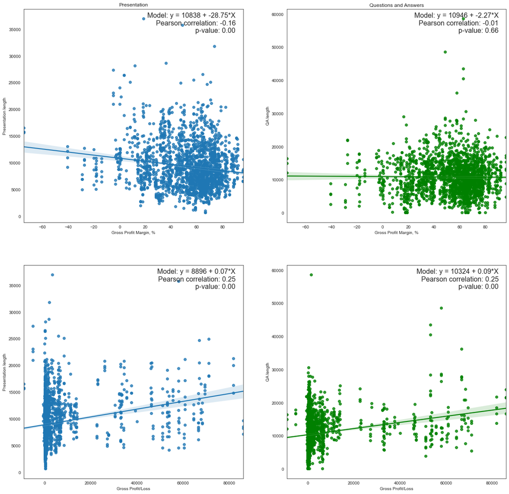

```python
# Calculate statistics
# GPM
correlation_PR_gpm, pvalue_PR_gpm = stats.pearsonr(df_parsed_mapped_PR["gpm"], df_parsed_mapped_PR["PR_len"])
correlation_QA_gpm, pvalue_QA_gpm = stats.pearsonr(df_parsed_mapped_QA["gpm"], df_parsed_mapped_QA["QA_len"])
slope_PR_gpm, intercept_PR_gpm = stats.linregress(df_parsed_mapped_PR["gpm"], df_parsed_mapped_PR["PR_len"])[0:2]
slope_QA_gpm, intercept_QA_gpm = stats.linregress(df_parsed_mapped_QA["gpm"], df_parsed_mapped_QA["QA_len"])[0:2]
# GP
correlation_PR_gp, pvalue_PR_gp = stats.pearsonr(df_parsed_mapped_PR["gp"], df_parsed_mapped_PR["PR_len"])
correlation_QA_gp, pvalue_QA_gp = stats.pearsonr(df_parsed_mapped_QA["gp"], df_parsed_mapped_QA["QA_len"])
slope_PR_gp, intercept_PR_gp = stats.linregress(df_parsed_mapped_PR["gp"], df_parsed_mapped_PR["PR_len"])[0:2]
slope_QA_gp, intercept_QA_gp = stats.linregress(df_parsed_mapped_QA["gp"], df_parsed_mapped_QA["QA_len"])[0:2]

# Plot the graph
sns.set_style("white")
fig, axes =plt.subplots(2,2,figsize=(20,20))
sns.regplot(x="gpm", y="PR_len", data=df_parsed_mapped_PR, ax=axes[0][0])
sns.regplot(x="gpm", y="QA_len", data=df_parsed_mapped_QA, color='green', ax=axes[0][1])
sns.regplot(x="gp", y="PR_len", data=df_parsed_mapped_PR, ax=axes[1][0])
sns.regplot(x="gp", y="QA_len", data=df_parsed_mapped_QA, color='green', ax=axes[1][1])

axes[0][0].set_title("Presentation")
axes[0][1].set_title("Questions and Answers")

for ax in axes[0]:
    ax.set_xlabel("Gross Profit Margin, %")

for ax in axes[1]:
    ax.set_xlabel("Gross Profit/Loss")

for subax in axes:
    subax[0].set_ylabel("Presentation length")
    subax[1].set_ylabel("QA length")


axes[0][0].annotate("".join((f'Model: y = {intercept_PR_gpm:.0f} + {slope_PR_gpm:.2f}*X\n',
                          f'Pearson correlation: {correlation_PR_gpm:.2f}\n',
                          f'p-value: {pvalue_PR_gpm:.2f}')),
                          xy=(0.95, 1), xytext=(8, -8), fontsize=16, ha='right', va='top',
                          xycoords='axes fraction', textcoords='offset points')

axes[0][1].annotate("".join((f'Model: y = {intercept_QA_gpm:.0f} + {slope_QA_gpm:.2f}*X\n',
                          f'Pearson correlation: {correlation_QA_gpm:.2f}\n',
                          f'p-value: {pvalue_QA_gpm:.2f}')),
                          xy=(0.95, 1), xytext=(8, -8), fontsize=16, ha='right', va='top',
                          xycoords='axes fraction', textcoords='offset points')

axes[1][0].annotate("".join((f'Model: y = {intercept_PR_gp:.0f} + {slope_PR_gp:.2f}*X\n',
                          f'Pearson correlation: {correlation_PR_gp:.2f}\n',
                          f'p-value: {pvalue_PR_gp:.2f}')),
                          xy=(0.95, 1), xytext=(8, -8), fontsize=16, ha='right', va='top',
                          xycoords='axes fraction', textcoords='offset points')

axes[1][1].annotate("".join((f'Model: y = {intercept_QA_gp:.0f} + {slope_QA_gp:.2f}*X\n',
                          f'Pearson correlation: {correlation_QA_gp:.2f}\n',
                          f'p-value: {pvalue_QA_gp:.2f}')),
                          xy=(0.95, 1), xytext=(8, -8), fontsize=16, ha='right', va='top',
                          xycoords='axes fraction', textcoords='offset points')
plt.show()
```

**Gross Profit Margin**: for QA, there is no correlation between the length of the session and profitability of the company; for Presentations, there is a week negative correlation. Therefore, Gross Profit Margin is not a good predictor for the length of the sessions.\ **Gross Profit/Loss**: for both Presentation and QA sessions, correlation, though being statistically significant, is only weakly positive (0,25). It suggests that Gross profit/loss is not a precise predictor of the length of the session, and other variables should be included in the model. However, there is a clear pattern in the lengths and GP, meaning that management tends to be more verbose when absolute numbers of Gross Profit are high. This is an intuitive result, since bigger banks have more specific information to share with investors and analysts.

# 3. Analyzing sentiments for the presentations before and during the 2008 financial crisis

A particularly popular method is counting word occurrences from word lists (dictionaries) that share common meanings. For example, dictionaries such as Harvard’s General Inquirer tag categories, Henry (2008), and Loughran and McDonald (2011) have been extensively used to measure the tone (sentiment) of documents.

To measure the sentiment, the frequency of each token in the document of the corpus is divided by the total number of words in the document, and then scaled by 100.

```python
# Download Loughran and McDonald dictionary; download Harvard dictionary
LM = pd.read_csv('https://www.dropbox.com/s/j35hfdxfy01ihio/LoughranMcDonald_MasterDictionary_2020.csv?dl=1')
HV=pd.read_csv("https://raw.githubusercontent.com/jmaxk/phrasal-sentiment/master/supplementary/inqtabs.txt", delimiter='\t',low_memory=False)
```

```python
# Choose dictionary classificators: negative, positive, uncertain
sentiments = ["negative", "positive", "uncertainty"]
```

```python
# Lowercase the columns for the ease of use
LM.columns = [column.lower() for column in LM.columns]
HV.columns = [column.lower() for column in HV.columns]
# Rename columns for the ease of use
HV.rename(columns={"entry": "word", "positiv": "positive", "negativ": "negative", "if": "uncertainty"}, inplace=True)
```

```python
# Remove words that have no sentiment
LM = LM[sentiments + ['word']]
LM.loc[:, sentiments] = LM.loc[:, sentiments].astype(bool)
LM = LM[(LM[sentiments]).any(1)].reset_index(drop=True)

HV = HV[sentiments + ['word']]
HV = HV[(HV[sentiments]).notnull().any(1)].reset_index(drop=True)
HV.loc[:, sentiments] = HV.loc[:, sentiments].notnull().astype(int)
HV.loc[:, sentiments] = HV.loc[:, sentiments].astype(bool)
```

```python
# Replace all nonalphabetical characters in HV
HV['word'] =  HV['word'].apply(lambda x: re.sub(r'[^A-Z]','', x))
```

```python
# Drop duplicate rows
HV.drop_duplicates(inplace=True, ignore_index=True)
```

```python
# Change the uppercase to lowercase
LM["word"] = LM["word"].str.lower()
HV["word"] = HV["word"].str.lower()
```

```python
def sentiment_analyzer(text: str, dictionary: str="LM") -> pd.Series:
    """
    Function calculates a scaled proportion of each sentiment in the text.
    Dictionary: "LM", "HV"
    """
    tokenized_text = nltk.word_tokenize(text)
    totalwords = len(tokenized_text)
    list_proportion = []
    # use the dictionary to calculate score of each sentiment in the text, performs faster then Counter()
    for sentiment in sentiments:
        if dictionary=="LM":
            sentiment_words = LM.loc[LM[sentiment],'word']
        elif dictionary=="HV":
            sentiment_words = HV.loc[HV[sentiment],'word']
        else:
            return
        dict_words = {word: 0 for word in sentiment_words}
        for word in tokenized_text:
            if word in dict_words:
                dict_words[word] += 1
        values = dict_words.values()
        total = sum(values)
        # scale by 100
        proportion_x100 = total / totalwords * 100
        list_proportion.append(proportion_x100)

    row = pd.Series(list_proportion, index=sentiments)
    return row
```

```python
# Create lists of sentiments for each dictionary
sentiments_LM = ["negative_LM", "positive_LM", "uncertainty_LM"]
sentiments_HV = ["negative_HV", "positive_HV", "uncertainty_HV"]
```

```python
%%time
# Append dataframe with sentiment scores from LM
df_parsed_mapped_PR[sentiments_LM] = df_parsed_mapped_PR["PR"].parallel_apply(sentiment_analyzer, args=("LM",))
```

```
CPU times: user 389 ms, sys: 135 ms, total: 525 ms
Wall time: 3.61 s
```

```python
%%time
# Append dataframe with sentiment scores from HV
df_parsed_mapped_PR[sentiments_HV] = df_parsed_mapped_PR["PR"].parallel_apply(sentiment_analyzer, args=("HV",))
```

```
CPU times: user 422 ms, sys: 140 ms, total: 562 ms
Wall time: 4.26 s
```

```python
# Sort by date
df_parsed_mapped_PR = df_parsed_mapped_PR.sort_values(by="Date")
df_parsed_mapped_PR = df_parsed_mapped_PR.reset_index(drop=True)
```

```python
# Resample the dataset quaterly
df_parsed_mapped_quarterly_PR = df_parsed_mapped_PR[['Date'] + sentiments_LM + sentiments_HV].resample('Q', on="Date").mean()
```

```python
# Filter the dataset for the period 2005-2009
df_parsed_mapped_quarterly_PR = df_parsed_mapped_quarterly_PR.loc['2005-01-01':]
```

```python
# Separate dataset into two for each dictionary
df_parsed_mapped_quarterly_PR_LM = df_parsed_mapped_quarterly_PR[sentiments_LM]
df_parsed_mapped_quarterly_PR_HV = df_parsed_mapped_quarterly_PR[sentiments_HV]
```

The beginning of the 2007-2008 Financial Crisis could be conditionally set to the mid 2007 year (*black vertical line on the graph*), when it became evident that the financial markets could not solve the subprime crisis and that the problems were reverberating well beyond the U.S. borders (https://www.investopedia.com/articles/economics/09/financial-crisis-review.asp#toc-august-2007-the-dominoes-start-to-fall).

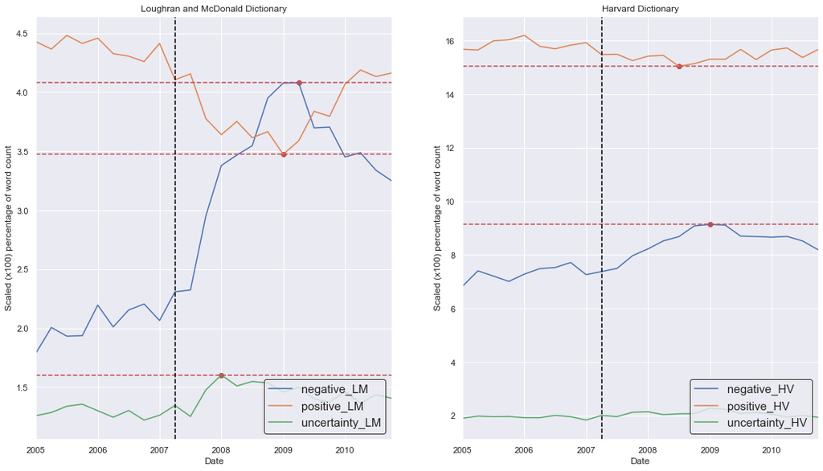

```python
# Plot the graph
sns.set_theme()

fig, axes =plt.subplots(1,2,figsize=(18,10))
df_parsed_mapped_quarterly_PR_LM.plot(ax=axes[0])
df_parsed_mapped_quarterly_PR_HV.plot(ax=axes[1])


axes[0].scatter([df_parsed_mapped_quarterly_PR_LM["negative_LM"].idxmax(),
              df_parsed_mapped_quarterly_PR_LM["positive_LM"].idxmin(),
              df_parsed_mapped_quarterly_PR_LM["uncertainty_LM"].idxmax()],
             [df_parsed_mapped_quarterly_PR_LM["negative_LM"].max(),
              df_parsed_mapped_quarterly_PR_LM["positive_LM"].min(),
              df_parsed_mapped_quarterly_PR_LM["uncertainty_LM"].max()], c='r')

axes[1].scatter([df_parsed_mapped_quarterly_PR_HV["negative_HV"].idxmax(),
              df_parsed_mapped_quarterly_PR_HV["positive_HV"].idxmin()],
             [df_parsed_mapped_quarterly_PR_HV["negative_HV"].max(),
              df_parsed_mapped_quarterly_PR_HV["positive_HV"].min()], c='r')

axes[0].legend(fontsize=15, loc="lower right", edgecolor="black")
axes[1].legend(fontsize=15, loc="lower right", edgecolor="black")

axes[0].axhline(y=df_parsed_mapped_quarterly_PR_LM["negative_LM"].max(), ls ="--", color="r")
axes[1].axhline(y=df_parsed_mapped_quarterly_PR_HV["negative_HV"].max(), ls ="--", color="r")
axes[0].axhline(y=df_parsed_mapped_quarterly_PR_LM["positive_LM"].min(), ls ="--", color="r")
axes[1].axhline(y=df_parsed_mapped_quarterly_PR_HV["positive_HV"].min(), ls ="--", color="r")
axes[0].axhline(y=df_parsed_mapped_quarterly_PR_LM["uncertainty_LM"].max(), ls ="--", color="r")

axes[0].axvline(x="2007-06-30 00:00:00+00:00", ls ="--", color="black")
axes[1].axvline(x="2007-06-30 00:00:00+00:00", ls ="--", color="black")

for ax in axes:
    ax.legend(fontsize=15, loc="lower right", edgecolor="black")
    ax.set_ylabel("Scaled (x100) percentage of word count")

axes[0].set_title("Loughran and McDonald Dictionary")
axes[1].set_title("Harvard Dictionary")

plt.show()
```

Based on this graph, the following conclusions can be drawn:

> 1. Both approches show the same tendency, where negative sentiments started to increase drastically at the beginning of the year 2007 and positive sentiments started to drop at the same period.
> 2. Sentiments began to fall before the crisis started to be widely covered in the media. In other words, the company's management anticipated the crisis before it became evident for non-professionals.
> 3. Sentiments began to revert back to its before-crisies values at the beginning of year 2009.
> 4. LM dictionary also shows that uncertainty sentiments peaked at the beginning of year 2008.
> 5. Apparently, LM dictionary better utilises the financial vocabulary then a general Harvard dictionary.

# 4. Checking any associations between the banks’ culture and banks’ failure risk during the crisis

To check the associations between the banks’ culture and banks’ failure risk during the crisis, the same approach as in the paper "Measuring corporate culture using machine learning" (Li et al. (2021)) was chosen. To calculate the banks' culture score, the authors used the weighted count of the number of words associated with each value divided by the total number of words in the document. The weight is tf.idf, with tf (term frequency) representing the word frequency in the document, and idf (inverse document frequency) denoting the inverse frequency of documents with the word in the corpus.

Also, as authors, we will adress the QA section of the Earning Call. The corpus will be filtered to Earning Calls before the beginning of the year 2008 in order to avoid the bias, since the management vocabulary might have changed in the times of crisis and after it.

```python
# Set date as index
df_parsed_mapped_QA_index_date = df_parsed_mapped_QA.set_index('Date')
```

```python
# Create a dataframe with data before 2008
df_parsed_mapped_QA_before_2008 = df_parsed_mapped_QA_index_date.loc[:"2008-01-01"].copy()
```

```python
# Create a corpus of QA sessions
corpus = df_parsed_mapped_QA_before_2008["QA"].tolist()
```

Create a dataframe with company culture scores for each Earning Call by summing the ranks of tokens row wise for each metric, based on the dictionary created by Li et al (2021).

```python
%%time
for metric in dictionary.columns:
    vectorizer=TfidfVectorizer(
        ngram_range=(1, 3), use_idf=True,
        analyzer='word', max_df=.20, min_df=1,
        max_features=None, vocabulary=dictionary[metric].dropna(),
        binary=False)
    tf_idf = vectorizer.fit_transform(corpus)
    df_parsed_mapped_QA_before_2008[metric] = tf_idf.toarray().sum(axis=1).tolist()
    print(f'{metric} is done')
```

```
integrity is done
teamwork is done
innovation is done
respect is done
quality is done
CPU times: user 11.2 s, sys: 38.6 ms, total: 11.2 s
Wall time: 11.3 s
```

```python
# Drop unnecessary columns
df_parsed_mapped_QA_before_2008.drop(columns=["gp", "QA", "QA_len", "gpm"], inplace = True)
```

```python
# Sort dataframe
df_parsed_mapped_QA_before_2008 = df_parsed_mapped_QA_before_2008.sort_values(by = ['CompanyName', 'Date'])
```

```python
# Create a dataframe with aggregated company culture scores (mean of culture scores for a particular company)
culture_df = df_parsed_mapped_QA_before_2008.groupby(by=["CompanyName"], as_index=False).mean()
```

```python
culture_df.head()
```

|  | CompanyName | integrity | teamwork | innovation | respect | quality |
| --- | --- | --- | --- | --- | --- | --- |
| 0 | American Express Co | 1.258506 | 1.828864 | 3.153956 | 1.841348 | 1.760703 |
| 1 | Bank of America Corp | 2.507485 | 2.219453 | 3.473089 | 1.532462 | 2.126753 |
| 2 | Bank of Hawaii Corp | 1.726000 | 1.527775 | 2.608715 | 1.439974 | 1.827043 |
| 3 | Bank of New York Mellon Corp | 1.791702 | 2.317321 | 3.084627 | 1.839898 | 1.835400 |
| 4 | Banner Corp | 1.530771 | 1.251075 | 2.007629 | 1.370145 | 1.502054 |

```python
# Create a list of banks from data
bank_names = culture_df["CompanyName"].tolist()
```

To check what banks have failed, two resources have been used:

1. FDIC Failed Banks list (https://www.fdic.gov/resources/resolutions/bank-failures/failed-bank-list/)
2. Wikipedia articles https://en.wikipedia.org/wiki/List_of_banks_acquired_or_bankrupted_during_the_Great_Recession and https://en.wikipedia.org/wiki/List_of_banks_acquired_or_bankrupted_in_the_United_States_during_the_financial_crisis_of_2007–2008 as a double check.

The banks' names from the Case dataset have been compared to the mentioned resources with the help of *fuzz* library.

```python
# Dataframe with failed banks from FDIC
failed_banks = pd.read_csv('https://www.fdic.gov/resources/resolutions/bank-failures/failed-bank-list/banklist.csv', encoding='windows-1252')
# Change to date format
failed_banks["Closing Date\xa0"] = pd.to_datetime(failed_banks["Closing Date\xa0"])
# Set date as index
failed_banks.set_index("Closing Date\xa0", inplace=True)
# Filter banks that failed before 2010
failed_banks = failed_banks.loc[:"2010-01-01"]
# Create a list of failed banks
failed_banks_list = failed_banks["Bank Name\xa0"].tolist()
# Check the names with Fuzz
for bank in bank_names:
    for failed_bank in failed_banks_list:
        if fuzz.token_sort_ratio(bank.lower(), failed_bank.lower()) > 70:
            print(f"{bank} is {failed_bank}")
```

```
Bank of America Corp is American Southern Bank
Bank of Hawaii Corp is Bank of Ephraim
Columbia Banking System Inc is Columbian Bank & Trust
Community Bank System Inc is Peoples First Community Bank
Community Bank System Inc is Platinum Community Bank
Community Bank System Inc is Community First Bank
Community Bank System Inc is Southern Community Bank
Community Bank System Inc is Heritage Community Bank
Community Bank System Inc is First Georgia Community Bank
Community Bank System Inc is Community Bank
First Republic Bank is Republic Federal Bank, N.A.
IndyMac Bancorp Inc is IndyMac Bank
Old National Bancorp is Omni National Bank
Old National Bancorp is Colorado National Bank
Old National Bancorp is Ocala National Bank
Old National Bancorp is National Bank of Commerce
Provident Financial Services Inc is FirstBank Financial Services
Signature Bank is Venture Bank
United Community Banks Inc is United Commercial Bank
United Community Banks Inc is United Security Bank
United Community Banks Inc is Riverview Community Bank
United Community Banks Inc is Platinum Community Bank
United Community Banks Inc is Community Bank of Nevada
United Community Banks Inc is Community First Bank
United Community Banks Inc is Southern Community Bank
United Community Banks Inc is Heritage Community Bank
Valley National Bancorp is Ocala National Bank
```

```python
# Upload CSV tables from Wikipedia
table_0 = pd.read_csv("table-0.csv")
table_1= pd.read_csv("table-1.csv")
table_2 = pd.read_csv("table-2.csv")
table_3 = pd.read_csv("table-3.csv")
table_4 = pd.read_csv("table-4.csv")
table_5 = pd.read_csv("table-5.csv")
# Create the list of failed banks
failed_banks_2 = table_0["Acquired company"].tolist() + table_1["Company"].tolist() + \
                 table_2["Company"].tolist() + table_3["Company"].tolist() + \
                 table_4["Company"].tolist()
# Check the names with Fuzz
for bank in bank_names:
    for failed_bank in failed_banks_2:
        if fuzz.token_sort_ratio(bank.lower(), failed_bank.lower()) > 61:
            print(f"{bank} is {failed_bank}")
```

```
American Express Co is American Home Mortgage
Bank of America Corp is Bank of Antigua
Bank of America Corp is American Sterling Bank
Bank of America Corp is American Southern Bank
CME Group Inc is PMI Group
Citigroup Inc is PMI Group
City National Corp is Cal National Bank
Community Bank System Inc is The Community Bank, Loganville, Georgia
Community Bank System Inc is Peoples Community Bank, West Chester, Ohio
Community Bank System Inc is Community Bank of Lemont, Lemont, Illinois
Federal Home Loan Mortgage Corp is American Home Mortgage
Federal National Mortgage Association is Republic Federal Bank, National Association, Miami, Florida
Federal National Mortgage Association is Marshall Bank, National Association, Hallock, Minnesota
First Republic Bank is First Merchant Bank
IndyMac Bancorp Inc is IndyMac Federal Bank
Lehman Brothers Holdings Inc is Lehman BrothersC
New York Community Bancorp Inc is Lehman Brothers, New York City B
Northern Trust Corp is Northern Rock
Old National Bancorp is Cal National Bank
Old National Bancorp is Ocala National Bank, Ocala, Florida
PNC Financial Services Group Inc is FirstBank Financial Services, McDonough, Georgia
PRA Group Inc is PMI Group
Provident Financial Services Inc is FirstBank Financial Services, McDonough, Georgia
SWS Group Inc is PMI Group
Signature Bank is Silver State Bank
Sterling Bancorp is American Sterling Bank
UMB Financial Corp is HSBC Finance Corporation
United Community Banks Inc is The Community Bank, Loganville, Georgia
United Community Banks Inc is Community First Bank, Prineville, Oregon
United Community Banks Inc is Community Bank of Lemont, Lemont, Illinois
Valley National Bancorp is Cal National Bank
Valley National Bancorp is Ocala National Bank, Ocala, Florida
```

As the result, only 4 banks that had Earning Calls before 2008 have failed.

```python
list_failed_final = ['IndyMac Bancorp Inc', 'Federal Home Loan Mortgage Corp',
                     'Lehman Brothers Holdings Inc', 'Federal National Mortgage Association']
```

```python
# Add a dummy variable: 1 if bank survived, 0 otherwise
culture_df["Survived"] = culture_df["CompanyName"].apply(lambda x: 0 if x in list_failed_final else 1)
```

To test the significance of each bank's culture metric, we will perform a regression analysis. Normally, for classification problems with binary outcomes {0,1}, Logistic Regression is used.  
However, the regression coefficients of such regression cannot be interpreted as weights to construct the overall culture score of the company; therefore, we will use Linear Regression for this purpose and then validate the results with the help of Logistic Regression.

```python
# check the dataset
print(culture_df["Survived"].value_counts())
```

```
1    79
0     4
Name: Survived, dtype: int64
```

The dataset is inbalanced and should be resampled.

```python
# Rebalance the dataset
# Separate majority and minority classes
df_majority = culture_df[culture_df.Survived==1]
df_minority = culture_df[culture_df.Survived==0]

# Upsample minority class
df_minority_upsampled = resample(df_minority,
                                 replace=True,   # sample with replacement
                                 n_samples=79,   # to match majority class
                                random_state=5)  # to match majority class

#Combine majority class with upsampled minority class
df_upsampled = pd.concat(objs=[df_majority, df_minority_upsampled], ignore_index=True)
```

```python
# Linear Regression
y = df_upsampled.iloc[:,6]
X = df_upsampled.iloc[:,1:6]
X['const'] = 1
model = sm.OLS(y, X).fit()
print_model = model.summary()
print(print_model)
```

```
                            OLS Regression Results
==============================================================================
Dep. Variable:               Survived   R-squared:                       0.589
Model:                            OLS   Adj. R-squared:                  0.576
Method:                 Least Squares   F-statistic:                     43.60
Date:                Tue, 25 Jan 2022   Prob (F-statistic):           1.02e-27
Time:                        16:07:36   Log-Likelihood:                -44.399
No. Observations:                 158   AIC:                             100.8
Df Residuals:                     152   BIC:                             119.2
Df Model:                           5
Covariance Type:            nonrobust
==============================================================================
                 coef    std err          t      P>|t|      [0.025      0.975]
------------------------------------------------------------------------------
integrity     -0.3310      0.119     -2.778      0.006      -0.566      -0.096
teamwork      -0.3360      0.115     -2.916      0.004      -0.564      -0.108
innovation    -0.2901      0.084     -3.469      0.001      -0.455      -0.125
respect       -0.5796      0.106     -5.455      0.000      -0.790      -0.370
quality        0.8413      0.143      5.886      0.000       0.559       1.124
const          2.1740      0.171     12.751      0.000       1.837       2.511
==============================================================================
Omnibus:                       15.510   Durbin-Watson:                   1.072
Prob(Omnibus):                  0.000   Jarque-Bera (JB):               18.003
Skew:                           0.826   Prob(JB):                     0.000123
Kurtosis:                       2.923   Cond. No.                         41.5
==============================================================================

Notes:
[1] Standard Errors assume that the covariance matrix of the errors is correctly specified.
```

All coefficients are statistically significant at 99% significance level. The model explains 58% of variance of the dependent variable. "Integrity", "Teamwork", "Innovation" and "Respect" scores have negative coefficients, which may suggest that regression overfits the results for such a small sample size.

To construct the final culture score, I use the following normalizer function to obtain the weights for each metric:

```python
# Calculate the normalizer, using: (1 / (sum of coefficients))
coeff_list = model.params[0:5].to_list()
normalizer = 1/float(sum(coeff_list))

# Multiply each item by the normalizer
weights = [x * normalizer for x in coeff_list]
print('Weights are \n{}\n'.format(weights))

print('Sum of all weights is {}'.format(sum(weights)))
```

```
Weights are
[0.47593232174603467, 0.48321992816135867, 0.4171675011903722, 0.8335095267321346, -1.2098292778299002]

Sum of all weights is 1.0000000000000002
```

```python
# Add constant to perform the elementwise multiplication
weights.append(0)
```

```python
# Set index
culture_df.set_index("CompanyName", inplace=True)
```

```python
# Add Culture Score table
culture_df["Culture Score"] = culture_df.mul(weights, axis=1).sum(axis=1)
```

```python
culture_df.head()
```

| CompanyName | integrity | teamwork | innovation | respect | quality | Survived | Culture Score |
| --- | --- | --- | --- | --- | --- | --- | --- |
| American Express Co | 1.258506 | 1.828864 | 3.153956 | 1.841348 | 1.760703 | 1 | 2.203065 |
| Bank of America Corp | 2.507485 | 2.219453 | 3.473089 | 1.532462 | 2.126753 | 1 | 2.419050 |
| Bank of Hawaii Corp | 1.726000 | 1.527775 | 2.608715 | 1.439974 | 1.827043 | 1 | 1.637803 |
| Bank of New York Mellon Corp | 1.791702 | 2.317321 | 3.084627 | 1.839898 | 1.835400 | 1 | 2.572362 |
| Banner Corp | 1.530771 | 1.251075 | 2.007629 | 1.370145 | 1.502054 | 1 | 1.495406 |

```python
# Validate with the Logistic Regression
df_upsampled.set_index("CompanyName", inplace=True)
df_upsampled["Culture Score"] = df_upsampled.mul(weights, axis=1).sum(axis=1)
y = df_upsampled["Survived"]
X = df_upsampled["Culture Score"]
logit_model=sm.Logit(y,X)
result=logit_model.fit()
print(result.summary2())
```

```
Optimization terminated successfully.
         Current function value: 0.678352
         Iterations 4
                        Results: Logit
===============================================================
Model:              Logit            Pseudo R-squared: 0.021
Dependent Variable: Survived         AIC:              216.3593
Date:               2022-01-25 16:07 BIC:              219.4219
No. Observations:   158              Log-Likelihood:   -107.18
Df Model:           0                LL-Null:          -109.52
Df Residuals:       157              LLR p-value:      nan
Converged:          1.0000           Scale:            1.0000
No. Iterations:     4.0000
---------------------------------------------------------------
                 Coef.  Std.Err.    z    P>|z|   [0.025  0.975]
---------------------------------------------------------------
Culture Score   -0.1405   0.0656 -2.1435 0.0321 -0.2690 -0.0120
===============================================================
```

Culture Score metrics is statistically significant at 95% percent significance level and each additional unit of Culture Score **decreases** the odds of Survival against Fail by the factor exp(0.1405) = 1.15

Interestingly, the regression coefficient for the final Culture score is negative (being statistically significant at 5% significance level), which is counterintuitive. Two explanations can be given:

1. Model overfits the data for such a small dataset.
2. Facing financial distress, the managment tries to enchance and boost the "language" during the meetings in order to cover the problems.

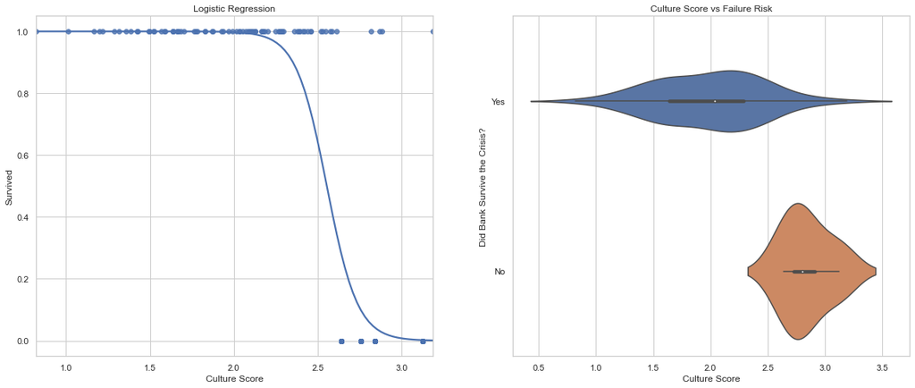

```python
# Visualuzation
# Ignore warnings which may appear during the caclulation of logistic regression curve
warnings.filterwarnings('ignore')

# Create a meaningful interpretation
culture_df["Did Bank Survive the Crisis?"] = culture_df["Survived"].apply(lambda x: "Yes" if x==1 else "No")

# Plot the graph
sns.set_theme(style="whitegrid")
fig, axes = plt.subplots(1,2,figsize=(20,8))
sns.regplot(x="Culture Score", y="Survived", data=df_upsampled, logistic=True, ax=axes[0])
sns.violinplot(x="Culture Score", y="Did Bank Survive the Crisis?", data=culture_df, orient='h', ax=axes[1])
axes[0].set_title("Logistic Regression", fontsize=12)
axes[1].set_title("Culture Score vs Failure Risk", fontsize=12)
plt.show()
```

The differernce for the Culture Score for two groups of banks is evident. However, this picture may be a result of the overfitting model due to the fact that sample size in not sufficient. It is suggested to obtain a bigger dataset and to test the model out-of-sample.

# 5. Checking which management teams have the most similar language to the management of Lehman Brothers

The most common text similarity metrics are Jaccard Similarity and Cosine Similarity.  
**Jaccard similarity** takes only unique set of words for each document and is good for cases where duplication does not matter. For example, for two product descriptions, it will be better to use Jaccard similarity as repetition of a word does not reduce their similarity.  
**Cosine similarity** calculates similarity by measuring the cosine of angle between two vectors. In other words, cosine similarity is good for cases where duplication matters while analyzing text similarity.  
One way to convert texts in the text is to use bag of words method with either **TF (term frequency)** or **TF-IDF (term frequency- inverse document frequency)**.  
Another way is to use pre-trained (for example Word2Vec) or custom word embeddings to convert words into vectors. Embeddings are the vector representations of text where word or sentences with similar meaning or context have similar representations.

In this project, I will use the Cosine similarity approach with 1) TF-IDF and 2) Word2Vec word embedding methods.  
Unlike TD, TF-IDF not only measures the word frequency, but also how importance of the word in the overall context. Word embedding, on the other hand, is capable of capturing context of a word in a document, semantic and syntactic similarity, relation with other words, etc.

```python
# Create a corpus of all transcripts
df_parsed_mapped["Full text"] = df_parsed_mapped["PR"] + df_parsed_mapped["QA"]

list_all_banks = df_parsed_mapped["CompanyName"].unique().tolist()

dict_bank_text = {bank: "transcript" for bank in list_all_banks}
for bank in list_all_banks:
    dict_bank_text[bank] = ' '.join(df_parsed_mapped["Full text"][df_parsed_mapped["CompanyName"] == bank])
```

## 5.1 TF-IDF

```python
# Initialise vectorizer
tfidfvectoriser=TfidfVectorizer()
tfidfvectoriser.fit(dict_bank_text.values())
tfidf_vectors=tfidfvectoriser.transform(dict_bank_text.values())
```

```python
# Create datafram
DTM = pd.DataFrame(tfidf_vectors.toarray(), index=dict_bank_text.keys())
```

```python
# Function calculates cosine similarity
def cosine_sim(A,B):
    return (np.inner(A,B))/(np.linalg.norm(A)* np.linalg.norm(B))
```

```python
# Create a dictionary that stores similarity
dict_of_similarities = {bank: "value" for bank in DTM.index.tolist()}

for bank in DTM.index.tolist():
    dict_of_similarities[bank] = cosine_sim(DTM.loc["Lehman Brothers Holdings Inc"], DTM.loc[bank])

dict_of_similarities.pop("Lehman Brothers Holdings Inc");
```

```python
# Dictionary to dataframe
df_of_similarities = pd.DataFrame(dict_of_similarities.values(),
                                  index=dict_of_similarities.keys(),
                                  columns=["Similarity to Lehman Brothers, TF-IDF"])
```

```python
df_of_similarities.sort_values(["Similarity to Lehman Brothers, TF-IDF"], ascending=False).head(10)
```

|  | Similarity to Lehman Brothers, TF-IDF |
| --- | --- |
| Raymond James Financial Inc | 0.476770 |
| Stifel Financial Corp | 0.473337 |
| Morgan Stanley | 0.465033 |
| Jefferies Group LLC | 0.426879 |
| Citigroup Inc | 0.423359 |
| Goldman Sachs Group Inc | 0.417929 |
| JPMorgan Chase & Co | 0.417631 |
| KeyCorp | 0.405437 |
| Boston Private Financial Holdings Inc | 0.405064 |
| Marketaxess Holdings Inc | 0.391487 |

Raymond James Financial Inc management had the most similar language to the Lehman Brothers.

## 5.2 Word2Vec

```python
# Tokenize and pad every document to make them of the same size
tokenizer=keras.preprocessing.text.Tokenizer()
tokenizer.fit_on_texts(dict_bank_text.values())
tokenized_documents=tokenizer.texts_to_sequences(dict_bank_text.values())
tokenized_paded_documents=pad_sequences(tokenized_documents,maxlen=64,padding='post')
vocab_size=len(tokenizer.word_index)+1
```

The model should be downloaded first from https://code.google.com/archive/p/word2vec/

```python
%%time
# Load pre-trained embeddings, each word is represented as a 300 dimensional vector
W2V_PATH="GoogleNews-vectors-negative300.bin.gz"
model_w2v = gensim.models.KeyedVectors.load_word2vec_format(W2V_PATH, binary=True)
```

```
CPU times: user 45.9 s, sys: 3.14 s, total: 49 s
Wall time: 50.6 s
```

```python
%%time
# Create embedding matrix, every row is a vector representation from the vocabulary indexed by the tokenizer index.
embedding_matrix=np.zeros((vocab_size,300))
for word,i in tokenizer.word_index.items():
    if word in model_w2v:
        embedding_matrix[i]=model_w2v[word]
# Create document-word embeddings
document_word_embeddings=np.zeros((len(tokenized_paded_documents),64,300))
for i in range(len(tokenized_paded_documents)):
    for j in range(len(tokenized_paded_documents[0])):
        document_word_embeddings[i][j]=embedding_matrix[tokenized_paded_documents[i][j]]
document_word_embeddings.shape
```

```
CPU times: user 218 ms, sys: 1.01 s, total: 1.23 s
Wall time: 3.87 s
```

```
(89, 64, 300)
```

```python
%%time
# Calculate average of word vectors of a document weighted by tf-idf
document_embeddings=np.zeros((len(tokenized_paded_documents),300))
words=tfidfvectoriser.get_feature_names_out()
for i in range(len(document_word_embeddings)):
       for j in range(len(words)):
            if words[j] in tokenizer.word_index:
                document_embeddings[i]+=embedding_matrix[tokenizer.word_index[words[j]]]*tfidf_vectors[i, j]
```

```
CPU times: user 1min 11s, sys: 1.79 s, total: 1min 12s
Wall time: 1min 17s
```

```python
DTM_W2V = pd.DataFrame(document_embeddings, index=dict_bank_text.keys())
```

```python
# Create a dictionary that stores similarity
dict_of_similarities_w2v = {bank: "value" for bank in DTM_W2V.index.tolist()}

for bank in DTM_W2V.index.tolist():
    dict_of_similarities_w2v[bank] = cosine_sim(DTM_W2V.loc["Lehman Brothers Holdings Inc"], DTM_W2V.loc[bank])

dict_of_similarities_w2v.pop("Lehman Brothers Holdings Inc");
```

```python
# Dictionary to dataframe
dict_of_similarities_w2v = pd.DataFrame(dict_of_similarities_w2v.values(),
                                  index=dict_of_similarities_w2v.keys(),
                                  columns=["Similarity to Lehman Brothers, W2V"])
```

```python
dict_of_similarities_w2v.sort_values(["Similarity to Lehman Brothers, W2V"], ascending=False).head(10)
```

|  | Similarity to Lehman Brothers, W2V |
| --- | --- |
| Jefferies Group LLC | 0.974781 |
| State Street Corp | 0.974119 |
| Citigroup Inc | 0.973432 |
| Goldman Sachs Group Inc | 0.972300 |
| Stifel Financial Corp | 0.972260 |
| Marketaxess Holdings Inc | 0.972107 |
| Bank of America Corp | 0.970135 |
| Morgan Stanley | 0.969521 |
| INTL FCStone Inc | 0.969293 |
| Community Bank System Inc | 0.968794 |

Jefferies Group LLC management had the most similar language to the Lehman Brothers.

```python
# Intersection of top 10 banks by 2 methods
set(df_of_similarities.sort_values(["Similarity to Lehman Brothers, TF-IDF"], ascending=False).head(10).index).intersection(
set(dict_of_similarities_w2v.sort_values(["Similarity to Lehman Brothers, W2V"], ascending=False).head(10).index))
```

```
{'Citigroup Inc',
 'Goldman Sachs Group Inc',
 'Jefferies Group LLC',
 'Marketaxess Holdings Inc',
 'Morgan Stanley',
 'Stifel Financial Corp'}
```

Two methods produce similar results, with 6 banks being represented in both top 10 lists.  
However, similarty scores in the second case are much higher then in previous example, suggesting that W2V takes advantage of financial context of Earnings Calls.